# Course Project 2: Storm Data

## Summary

This project involves exploring the U.S. National Oceanic and Atmospheric Administration’s (NOAA) [storm database](https://d396qusza40orc.cloudfront.net/repdata%2Fdata%2FStormData.csv.bz2). This database tracks characteristics of major storms and weather events in the United States, including when and where they occur, as well as estimates of any fatalities, injuries, and property damage.

The objective of this work is to find which types of weather events are most harmful to population health and which are those with the greatest economic consequences

## Data Processing

Setting the working directory, importing the data and creating two datsets. The Storm_harmful dataset will be used to answer which types of events are most harmful to population health. The Storm_economy dataset will be used to answer which types of events have the greatest economic consequences.

```r
setwd("C:/Users/S510U/Desktop")
Storm <- read.csv(file = "./repdata_data_StormData.csv.bz2")
Storm_harmful <-subset(Storm, select=c(EVTYPE,FATALITIES,INJURIES))
Storm_economy <-subset(Storm, select=c(EVTYPE,CROPDMG,CROPDMGEXP,PROPDMG,PROPDMGEXP))
```

## Results

### The effect of Weather events in Population Health

Creating a dataset to summarize the fatalities by weather event. Then, ordering the results and selecting the top ten with the highest values

```r
Storm_fatalities <- aggregate(FATALITIES ~ EVTYPE, data = Storm_harmful, sum)
max_fatalities <- Storm_fatalities[order(-Storm_fatalities$FATALITIES), ]
max_fatalities[1:10, ]
```

```
##             EVTYPE FATALITIES
## 834        TORNADO       5633
## 130 EXCESSIVE HEAT       1903
## 153    FLASH FLOOD        978
## 275           HEAT        937
## 464      LIGHTNING        816
## 856      TSTM WIND        504
## 170          FLOOD        470
## 585    RIP CURRENT        368
## 359      HIGH WIND        248
## 19       AVALANCHE        224
```

Creating a dataset to summarize the injuries by weather event. Then, ordering the results and selecting the top ten with the highest values

```r
Storm_injuries <- aggregate(INJURIES ~ EVTYPE, data = Storm, sum)
max_injuries <- Storm_injuries[order(-Storm_injuries$INJURIES), ]
max_injuries[1:10, ]
```

```
##                EVTYPE INJURIES
## 834           TORNADO    91346
## 856         TSTM WIND     6957
## 170             FLOOD     6789
## 130    EXCESSIVE HEAT     6525
## 464         LIGHTNING     5230
## 275              HEAT     2100
## 427         ICE STORM     1975
## 153       FLASH FLOOD     1777
## 760 THUNDERSTORM WIND     1488
## 244              HAIL     1361
```

Creating a dataset to summarize the fatalities + injuries by weather event. Then ordering the results and selecting the ten with the highest values

```r
Storm_harmful$HARM <- Storm_harmful$FATALITIES + Storm_harmful$INJURIES
Storm_harmful_total <- aggregate(HARM ~ EVTYPE, data = Storm_harmful, sum)
max_harmful <- Storm_harmful_total[order(-Storm_harmful_total$HARM), ]
max_harmful[1:10, ]
```

```
##                EVTYPE  HARM
## 834           TORNADO 96979
## 130    EXCESSIVE HEAT  8428
## 856         TSTM WIND  7461
## 170             FLOOD  7259
## 464         LIGHTNING  6046
## 275              HEAT  3037
## 153       FLASH FLOOD  2755
## 427         ICE STORM  2064
## 760 THUNDERSTORM WIND  1621
## 972      WINTER STORM  1527
```

Loading ggplot2 library and creating a barplot to show the Top Ten of weather events with the highest impact on Population Health

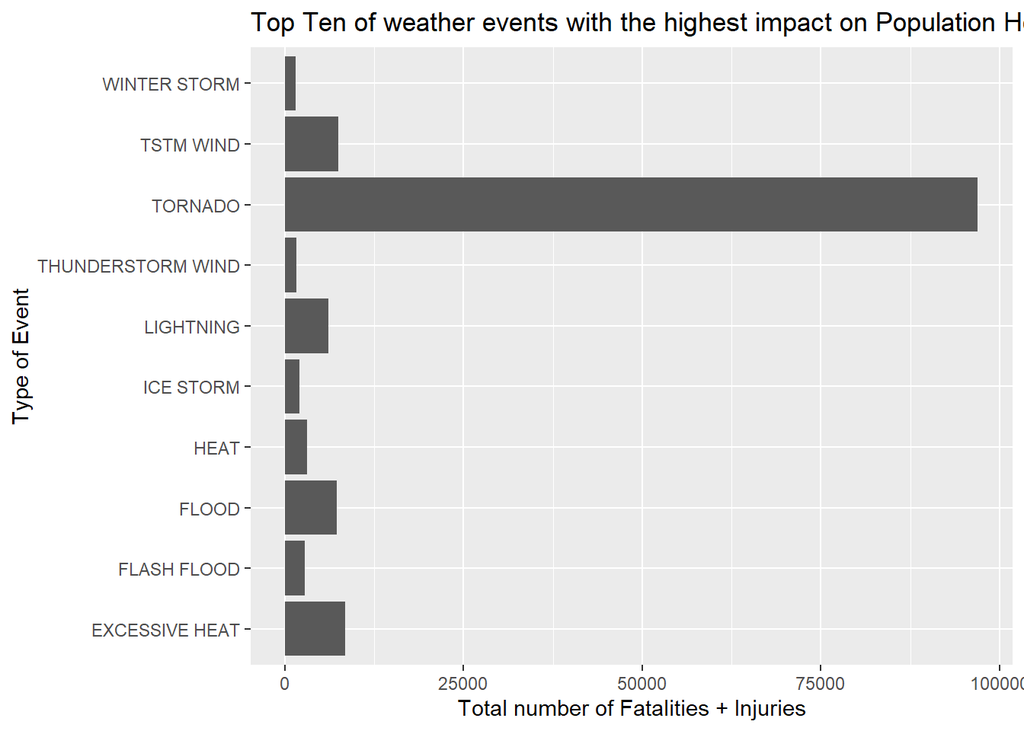

```r
library(ggplot2)
top10_harmful <- max_harmful[1:10, ]
top10_harmuful_plot <- ggplot(data = top10_harmful, aes(x=EVTYPE,y=HARM)) +
        geom_bar(stat="identity") +
        coord_flip() +
        xlab("Type of Event") +
        ylab("Total number of Fatalities + Injuries") +
        ggtitle("Top Ten of weather events with the highest impact on Population Health")
top10_harmuful_plot
```

### The effect of Weather events in Economy

Revisiting the factor levels of the PROPDMGEXP and CROPDMGEXP variables, we observe that these need to be edited to use it in posterior analyses

```r
levels(Storm_economy$PROPDMGEXP)
```

```
##  [1] ""  "-" "?" "+" "0" "1" "2" "3" "4" "5" "6" "7" "8" "B" "h" "H" "K" "m" "M"
```

```r
levels(Storm_economy$CROPDMGEXP)
```

```
## [1] ""  "?" "0" "2" "B" "k" "K" "m" "M"
```

Using the gsub() function to replace the original factor levels in the PROPDMGEXP variable for new values according to this [website](https://github.com/flyingdisc/RepData_PeerAssessment2/blob/master/how-to-handle-PROPDMGEXP.md)

```r
Storm_economy$PROPDMGEXP[Storm_economy$PROPDMGEXP == ""] <- NA
Storm_economy$PROPDMGEXP <- gsub("1", "10", Storm_economy$PROPDMGEXP)
Storm_economy$PROPDMGEXP <- gsub("NA", "1", Storm_economy$PROPDMGEXP)
Storm_economy$PROPDMGEXP <- gsub("\\-", "1", Storm_economy$PROPDMGEXP)
Storm_economy$PROPDMGEXP <- gsub("\\?", "1", Storm_economy$PROPDMGEXP)
Storm_economy$PROPDMGEXP <- gsub("\\+", "1", Storm_economy$PROPDMGEXP)
Storm_economy$PROPDMGEXP <- gsub("^0$", "1", Storm_economy$PROPDMGEXP)
Storm_economy$PROPDMGEXP <- gsub("h|H", "100", Storm_economy$PROPDMGEXP)
Storm_economy$PROPDMGEXP <- gsub("K", "1000", Storm_economy$PROPDMGEXP)
Storm_economy$PROPDMGEXP <- gsub("m|M", "1000000", Storm_economy$PROPDMGEXP)
Storm_economy$PROPDMGEXP <- gsub("B", "1000000000", Storm_economy$PROPDMGEXP)
Storm_economy$PROPDMGEXP <- gsub("2", "100", Storm_economy$PROPDMGEXP)
Storm_economy$PROPDMGEXP <- gsub("3", "1000", Storm_economy$PROPDMGEXP)
Storm_economy$PROPDMGEXP <- gsub("4", "10000", Storm_economy$PROPDMGEXP)
Storm_economy$PROPDMGEXP <- gsub("5", "100000", Storm_economy$PROPDMGEXP)
Storm_economy$PROPDMGEXP <- gsub("6", "1000000", Storm_economy$PROPDMGEXP)
Storm_economy$PROPDMGEXP <- gsub("7", "10000000", Storm_economy$PROPDMGEXP)
Storm_economy$PROPDMGEXP <- gsub("8", "100000000", Storm_economy$PROPDMGEXP)
```

Using the gsub() function to replace the original factor levels in the CROPDMGEXP variable for new values according to this [website](https://github.com/flyingdisc/RepData_PeerAssessment2/blob/master/how-to-handle-PROPDMGEXP.md)

```r
Storm_economy$CROPDMGEXP[Storm_economy$CROPDMGEXP == ""] <- NA
Storm_economy$CROPDMGEXP <- gsub("NA", "1", Storm_economy$CROPDMGEXP)
Storm_economy$CROPDMGEXP <- gsub("\\?", "1", Storm_economy$CROPDMGEXP)
Storm_economy$CROPDMGEXP <- gsub("^0$", "1", Storm_economy$CROPDMGEXP)
Storm_economy$CROPDMGEXP <- gsub("k|K", "1000", Storm_economy$CROPDMGEXP)
Storm_economy$CROPDMGEXP <- gsub("m|M", "1000000", Storm_economy$CROPDMGEXP)
Storm_economy$CROPDMGEXP <- gsub("B", "1000000000", Storm_economy$CROPDMGEXP)
Storm_economy$CROPDMGEXP <- gsub("2", "100", Storm_economy$CROPDMGEXP)
```

Creating a dataset to summarize the property damage by weather event. Then, ordering the results and selecting the top ten with the highest values

```r
Storm_economy$TOTALPROP <- Storm_economy$PROPDMG * as.numeric(Storm_economy$PROPDMGEXP)
Storm_property <- aggregate(TOTALPROP ~ EVTYPE, data = Storm_economy, sum)
max_property <- Storm_property[order(-Storm_property$TOTALPROP), ]
max_property[1:10, ]
```

```
##                EVTYPE    TOTALPROP
## 63              FLOOD 144657709800
## 181 HURRICANE/TYPHOON  69305840000
## 335           TORNADO  56947380674
## 283       STORM SURGE  43323536000
## 51        FLASH FLOOD  16822673772
## 105              HAIL  15735267456
## 173         HURRICANE  11868319010
## 343    TROPICAL STORM   7703890550
## 402      WINTER STORM   6688497251
## 158         HIGH WIND   5270046295
```

Creating a barplot to show the Top Ten of weather events with the highest Property damage

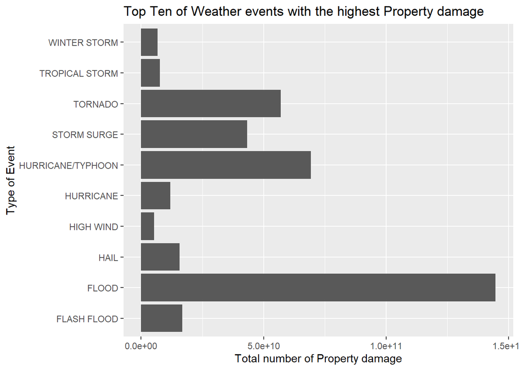

```r
top10_property <- max_property[1:10, ]
top10_property_plot <- ggplot(data = top10_property, aes(x=EVTYPE,y=TOTALPROP)) +
        geom_bar(stat="identity") +
        coord_flip() +
        xlab("Type of Event") +
        ylab("Total number of Property damage") +
        ggtitle("Top Ten of Weather events with the highest Property damage")
top10_property_plot
```

Creating a dataset to summarize the crop damage by weather event. Then, ordering the results and selecting the top ten with the highest values

```r
Storm_economy$TOTALCROP <- Storm_economy$CROPDMG * as.numeric(Storm_economy$CROPDMGEXP)
Storm_crop <- aggregate(TOTALCROP ~ EVTYPE, data = Storm_economy, sum)
max_crop <- Storm_crop[order(-Storm_crop$TOTALCROP), ]
max_crop[1:10, ]
```

```
##               EVTYPE   TOTALCROP
## 16           DROUGHT 13972566000
## 35             FLOOD  5661968450
## 99       RIVER FLOOD  5029459000
## 86         ICE STORM  5022113500
## 53              HAIL  3025954470
## 78         HURRICANE  2741910000
## 83 HURRICANE/TYPHOON  2607872800
## 30       FLASH FLOOD  1421317100
## 26      EXTREME COLD  1292973000
## 47      FROST/FREEZE  1094086000
```

Creating a barplot to show the Top Ten of weather events with the highest Crop damage

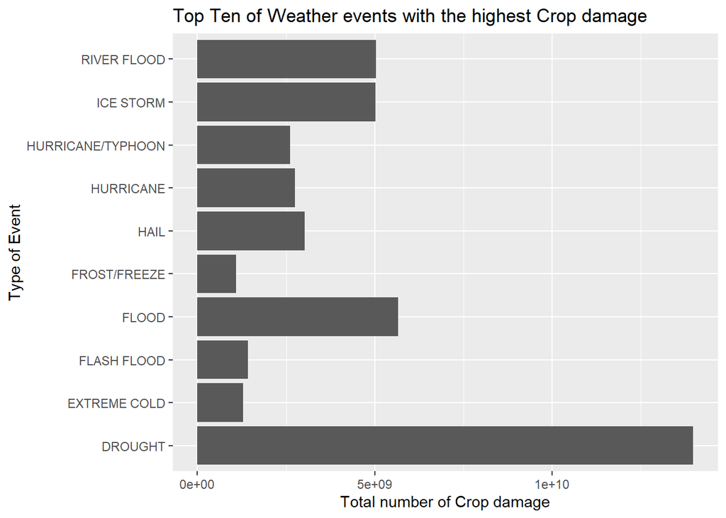

```r
top10_crop <- max_crop[1:10, ]
top10_crop_plot <- ggplot(data = top10_crop, aes(x=EVTYPE,y=TOTALCROP)) +
        geom_bar(stat="identity") +
        coord_flip() +
        xlab("Type of Event") +
        ylab("Total number of Crop damage") +
        ggtitle("Top Ten of Weather events with the highest Crop damage")
top10_crop_plot
```

## Conclusions

_ The most harmful weather event to population health in the U.S. is Tornado.

_ The weather event that produces the highest propiety damage in the U.S. is Flood

_ The weather event that produces the highest crop damage in the U.S. is Drought